# Visualization Tutorial

### Leonardo Alchieri, Università della Svizzera Italiana

#### 10 Nov 2025, Istituto Nazionale dei Tumori, Milano

## Example Description

I simulated data for a clinical trial. We have 100 patients randomized to three arms: High-dose treatment, Low-dose treatment and Placebo (control). We measure two biomarkers at 5 time points: 0, 1, 2, 4, 5. The actual value of the timepoints is not important for the tutorial. We separate the patients into responders and non-responders, based on their response to the treatment.

**Disclaimer**: The data is completely simulated and does not represent any real clinical trial.

You can find the data in `./data/clinical-example-1.xlsx`

### What we will do

- Learn how to load data from Excel
- Learn how to manipulate data with `pandas` library
- Learn how to create displots with the `seaborn` library
- Learn how to create lineplots with the `seaborn` library
- Learn how to create boxplots with the `seaborn` library

# Necessary Packages

## You need to install the following packages

- `pandas`
- `seaborn`
- `matplotlib`
- `openpyxl`

### Do you remember how to install packages?

### Double check that everything is working as expected

```python
import pandas as pd
import seaborn as sns
import matplotlib.pyplot as plt
```

## Loading and exploring the data

```python
data = pd.read_excel('./data/clinical-example-1.xlsx')
display(data.head())
```

|  | ID | ARM | TimePoint | Risposta | Basophils | Neutrophils |
| --- | --- | --- | --- | --- | --- | --- |
| 0 | 1 | High Dose | T1 | Responder | 12018.795950 | 11347.932198 |
| 1 | 1 | High Dose | T2 | Responder | 30001.500000 | 12000.600000 |
| 2 | 1 | High Dose | T3 | Responder | 18000.900000 | 45002.250000 |
| 3 | 1 | High Dose | T4 | Responder | 24001.200000 | 24001.200000 |
| 4 | 1 | High Dose | T5 | Responder | 44291.937567 | 74879.138932 |

### Calculate the average Basophils count for each time point, for the "High-dose" treatment arm and "Responders" only

```python
data_subset = data[(data["ARM"] == "High Dose")
                   & (data["Risposta"] == "Responder")]
display(data_subset.head())
```

|  | ID | ARM | TimePoint | Risposta | Basophils | Neutrophils |
| --- | --- | --- | --- | --- | --- | --- |
| 0 | 1 | High Dose | T1 | Responder | 12018.795950 | 11347.932198 |
| 1 | 1 | High Dose | T2 | Responder | 30001.500000 | 12000.600000 |
| 2 | 1 | High Dose | T3 | Responder | 18000.900000 | 45002.250000 |
| 3 | 1 | High Dose | T4 | Responder | 24001.200000 | 24001.200000 |
| 4 | 1 | High Dose | T5 | Responder | 44291.937567 | 74879.138932 |

```python
for time_point in data_subset['TimePoint'].unique():

    subset_tp = data_subset[data_subset['TimePoint'] == time_point]

    mean_basophils = subset_tp['Basophils'].mean()

    print(f"TimePoint: {time_point}, Mean Basophils: {mean_basophils}")
```

```
TimePoint: T1, Mean Basophils: 9240.681433352906
TimePoint: T2, Mean Basophils: 24609.98379946011
TimePoint: T3, Mean Basophils: 31806.29161610137
TimePoint: T4, Mean Basophils: 44363.590760421095
TimePoint: T5, Mean Basophils: 59920.953483363526
```

# Plotting Distributions

`Seaborn` is a high-level data visualization library. Seaborn relies on the `pandas` DataFrame structure.

### Plot distribution of "Basophils" count for Non-Responders at TimePoint 2, for the "Low Dose" treatment arm

```python
data_subset = data[
    (data["ARM"] == "Low Dose")
    & (data["Risposta"] == "Non-Responder")
    & (data["TimePoint"] == "T2")
]
display(data_subset.head())
```

|  | ID | ARM | TimePoint | Risposta | Basophils | Neutrophils |
| --- | --- | --- | --- | --- | --- | --- |
| 26 | 6 | Low Dose | T2 | Non-Responder | 5000.000000 | 20000.000000 |
| 71 | 15 | Low Dose | T2 | Non-Responder | 5000.000000 | 20000.000000 |
| 91 | 19 | Low Dose | T2 | Non-Responder | 18003.309561 | 20000.000000 |
| 116 | 24 | Low Dose | T2 | Non-Responder | 15214.789552 | 14599.914729 |
| 131 | 27 | Low Dose | T2 | Non-Responder | 15946.453460 | 5000.000000 |

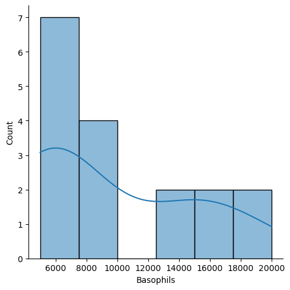

```python
sns.displot(data=data_subset, x="Basophils", kde=True)
plt.show()
```

### You can use `displot` to also have 2D distributions

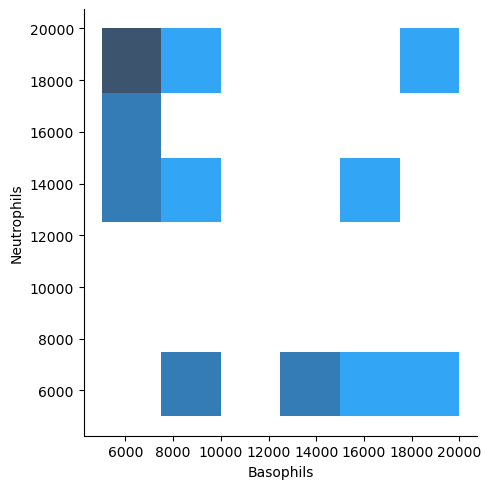

```python
sns.displot(data=data_subset, x="Basophils", y="Neutrophils")
plt.show()
```

### Seaborn also allows to easily plot the distrbution across multiple categories

Let's compare the distributions of Basophils count at TimePoint 2, for Responders and Non-Responders, in the "Low Dose" treatment arm

```python
data_subset = data[
    (data["ARM"] == "Low Dose")
    & (data["TimePoint"] == "T2")
]
display(data_subset.head())
```

|  | ID | ARM | TimePoint | Risposta | Basophils | Neutrophils |
| --- | --- | --- | --- | --- | --- | --- |
| 6 | 2 | Low Dose | T2 | Responder | 10005.000000 | 10005.0 |
| 26 | 6 | Low Dose | T2 | Non-Responder | 5000.000000 | 20000.0 |
| 46 | 10 | Low Dose | T2 | Responder | 39369.781543 | 10005.0 |
| 61 | 13 | Low Dose | T2 | Responder | 40020.000000 | 40020.0 |
| 71 | 15 | Low Dose | T2 | Non-Responder | 5000.000000 | 20000.0 |

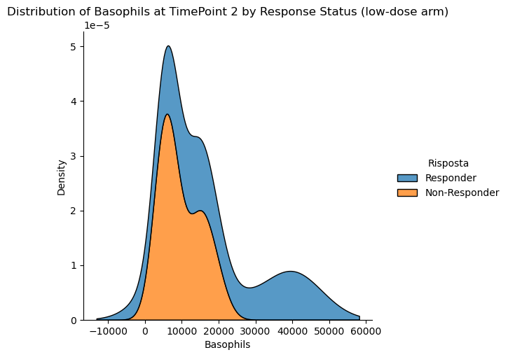

```python
sns.displot(
    data=data_subset,
    x="Basophils",
    kind="kde",
    hue="Risposta",
    multiple="stack"
)
plt.title("Distribution of Basophils at TimePoint 2 by Response Status (low-dose arm)")
plt.show()
```

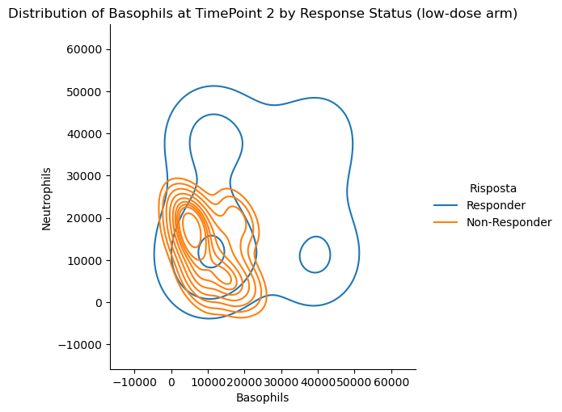

```python
sns.displot(
    data=data_subset,
    x="Basophils",
    y="Neutrophils",
    kind="kde",
    hue="Risposta"
)
plt.title("Distribution of Basophils at TimePoint 2 by Response Status (low-dose arm)")
plt.show()
```

### Making sub-plots automatically

`Seaborn` allows to create subplots automatically, using the `col` and `row` arguments in `displot`.

Let's plot now the distribution of Basophils count at TimePoint 2, for Responders and Non-Responders, for all types of treatment arms.

```python
data_subset = data[
    (data["TimePoint"] == "T2")
]
display(data_subset.head())
```

|  | ID | ARM | TimePoint | Risposta | Basophils | Neutrophils |
| --- | --- | --- | --- | --- | --- | --- |
| 1 | 1 | High Dose | T2 | Responder | 30001.500000 | 12000.600000 |
| 6 | 2 | Low Dose | T2 | Responder | 10005.000000 | 10005.000000 |
| 11 | 3 | High Dose | T2 | Responder | 12000.600000 | 30001.500000 |
| 16 | 4 | High Dose | T2 | Responder | 27237.592806 | 30001.500000 |
| 21 | 5 | High Dose | T2 | Responder | 30001.500000 | 29447.297843 |

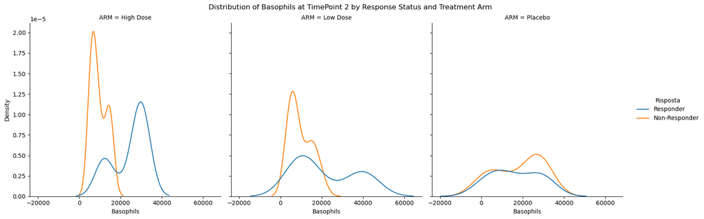

```python
sns.displot(
    data=data_subset,
    x="Basophils",
    kind='kde',
    hue="Risposta",
    col='ARM'
    )

plt.suptitle("Distribution of Basophils at TimePoint 2 by Response Status and Treatment Arm", y=1.02)
plt.savefig("data/displot_facet_arm.pdf", bbox_inches='tight')
plt.show()
```

## Your turn!

Now, try to plot the distribution of "Neutrophils" for Responders and Non-Responders, at all timepoints (rows) and for all treatment arms (columns).

# Boxplot!

Now you should have a good idea of how to use `seaborn`. I'll you an example, and then you can try by yourself!

```python
data_subset = data[
    (data["ARM"] == "High Dose")
]
display(data_subset.head())
```

|  | ID | ARM | TimePoint | Risposta | Basophils | Neutrophils |
| --- | --- | --- | --- | --- | --- | --- |
| 0 | 1 | High Dose | T1 | Responder | 12018.795950 | 11347.932198 |
| 1 | 1 | High Dose | T2 | Responder | 30001.500000 | 12000.600000 |
| 2 | 1 | High Dose | T3 | Responder | 18000.900000 | 45002.250000 |
| 3 | 1 | High Dose | T4 | Responder | 24001.200000 | 24001.200000 |
| 4 | 1 | High Dose | T5 | Responder | 44291.937567 | 74879.138932 |

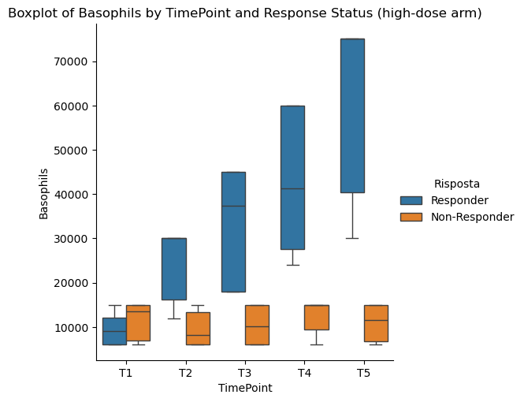

```python
sns.catplot(
    data=data_subset, y='Basophils', x='TimePoint', hue="Risposta",
    kind='box'
    )

plt.title("Boxplot of Basophils by TimePoint and Response Status (high-dose arm)")
plt.show()
```

## Your turn!

Create a violin plot of Basophils count across TimePoints, for Responders and Non-Responders, in the "High Dose" treatment arm. Use rows and columns as before!

# Lineplot

When you have temporal data (line the timepoints in our example), you can use lineplots to visualize trends over time.

```python
data_subset = data[(data['ARM'] == 'High Dose')
                   & (data['Risposta'] == 'Responder')]
```

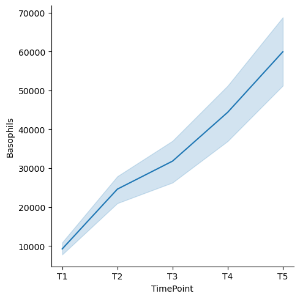

```python
sns.relplot(
    data=data_subset, x='TimePoint',y='Basophils', kind='line',
    )

plt.show()
```

#### It automatically computes the mean and confidence intervals (95% by default) for each timepoint.

## Your turn!

Make a lineplot to compare, for the "Basophils" count, the trends over time between Responders and Non-Responders, in all treatment arms.

# References

https://seaborn.pydata.org/generated/seaborn.relplot.html

https://seaborn.pydata.org/generated/seaborn.displot.html

https://seaborn.pydata.org/generated/seaborn.catplot.html